# Meta-analysis of meta-analyses pipeline

Christina Raw

9/5/2022

# What is a meta-analyis

A meta-analysis is a statistical analysis of results of individual studies to integrate and contrast them (Glass, 1976). It allows to observe an overall effect, formulate hypotheses, and find research gaps (Katayama et al., 2019). It also allows to perform moderator analyses to test possible sources of heterogeneity in the results.

As a visual example:

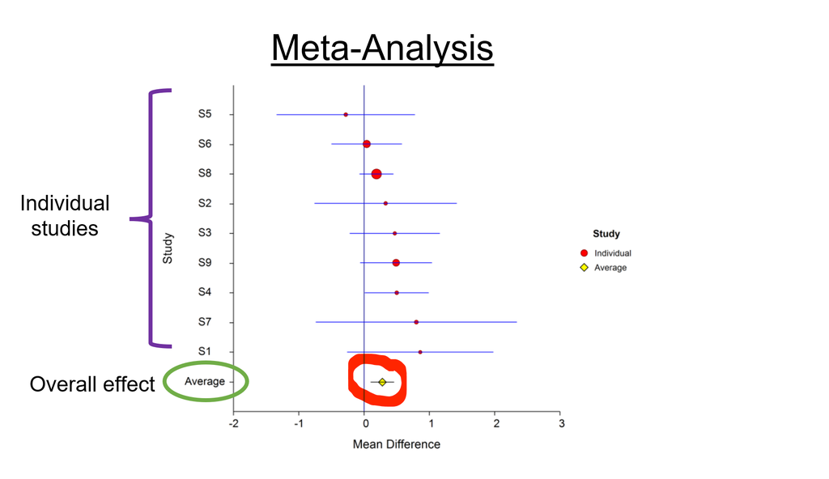

# Steps in a meta-analysis

For a more information on the steps 1 to 5, read the meta-methods document, which can be found in the resources folder.

## 1. formulation

What is the research question? To formulate the research question, apply the PICO framework: define the Population, Intervention, Comparator, and the Outcome of interest.

*Example*: what is the impact of sustainable agricultural production systems on biodiversity relative to conventional production systems?

- Population: biodiversity
- Intervention: sustainable agricultural production systems
- Comparator: conventional agriculture
- Outcome: biodiversity metric

**Problem**: the research question could be too broad, leading to very time-consuming scoping and screening phases. It can also limit the sample size and the power of the analysis as it could create a situation of “Jack of all trades, master of none”. Therefore, it is recommended to narrow down the question.

*Example*: what is the impact of organic agriculture on arachnid species abundance and richness relative to conventional agriculture?

- Population: arachnids
- Intervention: organic agriculture
- Comparator: conventional agriculture
- Outcome: arachnid quantitative species abundance and species richness

This question defines the studies relevant to the research question: studies that provide a quantitative measure of arachnid species richness and abundance under organic agriculture compared to conventional agriculture. It also defines the type of effect size that will be used in the meta-analysis and therefore that data that will be extracted from the included studies.

*Examples of effect size*: in this case, as the goal is to compare a pair of means under different treatments, an effect size that compares means would be the right choice. The log response ratio or the standardized mean difference effect sizes would work. For more information on effect size estimates see Julia Koricheva’s et al., book, found in resources > Handbook_of_Meta-Analysis_in_Ecology_and_Evolution.pdf

**Document**: provide a description of the PICO elements that form your research question. These descriptions will be included in the protocol (see below).

## 3. Scoping phase

What is the available volume of literature relevant to the research question? The answer to this question will determine whether the meta-analysis can be done or whether some changes have to be made to the project design. Therefore, the review scoping helps to design the meta-analysis and develop an appropriate systematic review protocol.

### 3.1 Develop the optimal string of search terms

1. Gather as many relevant search terms as possible
2. Remove terms already covered by other terms (e.g., “species richness” is covered by richness) and collapse terms that overlap by using wildcards (e.g., compare, comparison -> compar*). c. Test proto string of search terms

#### 3.1.1. Proto-string of search terms

From scientific literature related to the topic, gather relevant terms that cover the PICO elements, then construct the proto string of search terms by combining the terms using Boolean operators and wild cards.

*Basic example:*

- Population: arthropod, arachnid*, spider, araneae
- Intervention: organic OR conventional
- Comparator: compar*, contrast*
- Outcome: richness, abundance.

Proto-string of search terms*:

*(Arthropod OR arachnid* OR spider OR Araneae OR aran*) AND (organic OR conventional) AND (compar*OR contrast*) AND (richness OR abundance).

#### 3.1.2. Refine the string of search terms

Test the proto-string of search terms by an iterative process of inclusion-exclusion of terms. Perform a search in the data base using the proto-string of search terms and record how many relevant papers are returned in the first 20 abstracts. Is a term returning a high number of irrelevant papers? For example, the term arthropod might retrieve many papers that focus on species other than arachnids, which are not relevant to the research question. Therefore, drop the term arthropod and perform a new search.

*Extra method*: litsearchr 1.0.0 (Grames et al., 2020) is an R package that helps build optimal string of search terms as it facilitates quick, objective, reproducible search strategy development using text-mining and keyword co-occurrence networks to identify important terms to include in a search strategy.

**Document**: for each iteration, record the string of search terms used, modifications made, number of hits and number of relevant papers in the first 20 abstracts.

#### 3.2. Develop a systematic review protocol

This is the protocol that will be followed when performing the systematic literature review. The ROSES systematic review protocol includes the following elements: title, objective of the overview, definitions of the question components, search strategy, search string, bibliographic databases used, inclusion criteria, screening strategy, critical appraisal, meta-data extraction and coding strategy, data extraction strategy, approaches to missing data, effect modifiers, risk of bias, author contribution and competing interests.

More information on ROSES systematic review protocol can be found in the ROSES website: https://www.roses-reporting.com/systematic-review-protocols

**Document**: provide a systematic review protocol in your supplementary material.

## 4. Screening

### 4.1. Download studies

Perform a database search using the optimal string of search terms. Use both primary and secondary data bases. The search in secondary data bases helps find grey literature and therefore reduce publication bias. Examples of primary data bases are Scopus or Web of Science. Secondary data bases depend on the research question, some examples could be Google Scholar, (…).

Download the studies retrieved by the data base using your optimal string of search terms.

**Document**: data bases searched, number of hits returned, any filters applied. If the different databases requite tailoring of the string of search terms, document all the versions of the string of search terms used in the different data bases.

### 4.2. Deduplication

Download all the studies returned in the searches and remove the duplicates. To do so, use a reference manager such as EndNote or Mendeley and apply the deduplication protocol described Bramer et al., (2016).

**Document:** take note of the number of duplicates discarded.

### 3.3. Screen for relevance

Screen the deduplicated list of studies to search for studies relevant to the research question following the inclusioncriteria established in the protocol.

*Example*: I will screen the list to search for studies that assess the impact of organic agricultural production systems on arachnid species abundance and species richness relative to conventional production systems.

To speed up the process, perform two or even three rounds of screening for relevant papers. In the first round, screen the titles and abstracts of the list of papers and discard all studies that are obviously irrelevant to the research question. In the second round, screen more meticulously the title and abstract of the remaining papers. In the third round I perform a full-text screen of the remaining papers to check for relevance. Extra method: use the MetaGear 0.7 package (Lajeunesse, 2016) R package, a tool to screen titles and abstracts for relevance.

**Document:** - Assign an exclusion reason to the excluded papers. The exclusion reason for the studies excluded in the first round is “not relevant”. The exclusion reason(s) of the studies rejected in the second and third round can be many, e.g., not relevant, does not include biodiversity measure, does not compare organic and conventional production systems, etc. - Provide a list of the exclusion reasons with the number of papers rejected per exclusion reason. - Provide a list of the references of the included and excluded studies. - Provide a flow diagram that documents the screening process (ROSES, 2022c).

## 5. Data extraction phase

Extract the data from the relevant papers.

### 5.1. Data extraction spread sheet

Build an excel data extraction spread sheet where the extracted data will be recorded. Data includes information about the study (e.g., study ID, authors, title, etc.), quantitative variables that will be used to calculate the effect size, and qualitative variables that will be used for moderator analysis. The quantitative variables recorded will depend on the effect size chosen to perform the meta-analysis, e.g., if performing the meta-analysis using the Log Response Ratio effect size, then mean and variance under each treatment should be recorded.

*Extra method*: use the metaDigitise 0.7 (Lajeunesse, 2016) R package to extract data from figures

*Example of variables recorded in the data extraction spread sheet:*

- Information about the study: study id, authors, title, URL, year, journal, volume, issue, pages, month, DOI, abstract, database.
- Qualitative variables: country, geographical coordinates (latitude, longitude), biome, crop, phylum, class, order, family, genus, species, functional group, control and intervention (conventional and organic), tillage use, pesticide use, biodiversity metric (richness or abundance), data extracted from, etc.
- Quantitative variables: sample size, mean, standard deviation, quality score, etc.

### 5.2. Pilot the data extraction spread sheet

Pilot the data extraction spread sheet using a random sample of ten studies from the pool of relevant studies. Remove irrelevant variables or add variables.

**Document:** provide a list of all the variables included in the data extraction spreadsheet and a brief description. Provide a list of the variables removed and added after the piloting of the spread sheet. In the case that data transformations are needed, provide the data transformation methodologies and document on which studies they were performed.

### 5.3. Data extraction

Extract the data from the relevant papers and record it in the data extraction spread sheet.

## 6. Effect size calculation

Depending on the research question, different methodologies can be applied to perform a meta-analysis. For a detailed description of how to perform different types of meta-analyses in R, see (Viechtbauer, 2010). For a tutorial on multi-level meta-analysis, Assink & Wibbelink (2016).

### 7.1 Senitivity analysis

A sensitivity analysis to study the effect of lower quality studies on the results is recommended. Conduct a sensitivity analysis to assess the robustness of the results of the complete model when excluding studies of lower quality from the analysis.

### 7.2. Bias asessment

Something else to consider is the assessment of bias. There are different types of bias that can arise in meta-analyses, such as:

- Publication bias: this type of bias can be assessed with a funnel plot and reduced by including grey literature.
- Reviewer bias: it can be assessed kappa test.
- Language bias: can by reduced by included papers written in different languages.

**Document:** provide a figure that assesses the bias such as a funnel plot.

# This meta-analysis and your tasks

But, in this case, instead of a meta-analysis, we are going to perform a meta-meta-analysis. The steps are the same as those for a meta-analysis. The difference is that our sources of data will be reviews and meta-analyses, instead of individual studies.

The goal of this meta-review is to sum up existing information on the impact of different cropping and livestock systems on biodiversity. I will create a “gradient” that categorises each farming system’s impact on biodiversity, from least to most impactful.

The idea is to see what is known about the relative biodiversity impact of the main ways of farming.

## 1. Question

Primary question: How do the production systems of top global crops and livestock impact biodiversity?

## 2. Scoping phase

### 2.1 String of search terms

I used the string of search terms found in resources > scoping phase > strings of search terms. You can find the process of development of the optimal string of search terms in the same document.

### 2.2. Systematic review protocol

You can find an example of the systematic review protocol in resources > scoping phase > systematic review protocol

**TASK:** try to develop an optimal string of search terms for one of the crops, similar to the one I used but maybe including more terms